[O’Hara on GitHub](https://github.com/oharac)

# Map vulnerability, unweighted, including only FE spp

Compiled on Wed Mar 23 07:54:34 2022 by ohara

```r
knitr::opts_chunk$set(echo = TRUE, message = FALSE, warning = FALSE)

library(raster)
library(oharac)
library(tidyverse)
library(here)
source(here('common_fxns.R'))
```

# 1 Summary

Apply vulnerability scores to mapped species. Map out vulnerability to each stressor, first unweighted by species (each spp counts same, this script), then weighted by functional vulnerability (FEs with higher FV are given greater weight, script 3).

# 2 Data

- AquaMaps and IUCN rangemaps
- Vulnerability Framework data for vulnerability scores
- FishBase/SeaLifeBase and vulnerability framework data for functional entity assignments

# 3 Methods

## 3.1 Unweighted, by species

Read in AquaMaps and IUCN maps and vulnerability scores. AquaMaps maps will exclude species with fewer than 10 occurrence cells, and will use a probability threshold of 0.5. Here, we include the same spp as script 3a (mapped $\cap$ trait-based vulnerability $\cap$ functional entity) except without the functional vulnerability weighting.

Iterating over each stressor, calculate cell-by-cell mean (and standard deviation?).

- At the 10 km Mollweide resolution, rather than HCAF resolution, we will probably have to chunk this out and then add the pieces together.
- Processing by taxonomic group first, then combining.

```r
spp_am <- get_am_spp_info()  %>%
  filter(occur_cells >= 10) %>%
  select(species = sciname) %>%
  mutate(am_mapped = TRUE) %>%
  distinct()

spp_iucn <- read_csv(here('_data/iucn_spp/iucn_to_worms_match.csv'), show_col_types = FALSE) %>%
  rename(species = worms_name, iucn_mapped = mapped)

spp_vuln <- get_spp_vuln(gapfill = 'family') %>%
  select(species, stressor, taxon, score, sd_score)  %>%
  mutate(vuln = TRUE) %>%
  distinct()

spp_worms <- assemble_worms() %>%
  select(species) %>%
  mutate(worms = TRUE) %>%
  distinct()

spp_fe <- read_csv(here('_output/func_entities/fe_species.csv'), show_col_types = FALSE)

all_spp <- spp_worms %>%
  full_join(spp_vuln, by = 'species') %>%
  full_join(spp_am,   by = 'species') %>%
  full_join(spp_iucn, by = 'species') %>%
  full_join(spp_fe,   by = 'species')

spp_for_vuln_calc <- all_spp %>%
  ### names in WoRMS
  filter(worms) %>%
  ### only those spp in vulnerability project?
  filter(vuln) %>%
  ### mapped in AquaMaps and/or IUCN
  filter(am_mapped | iucn_mapped) %>%
  ### and with valid FE classification
  filter(!is.na(fe_id))
```

### 3.1.1 Taxon-by-taxon vulnerability maps

Loop over each stressor, then over each taxon. Generate a mean and sd vulnerability map for each combination; save to Mazu.

```r
strs <- spp_for_vuln_calc$stressor %>% unique() %>% sort()
taxa <- spp_for_vuln_calc$taxon %>% unique() %>% sort()

# spp_for_vuln_calc %>%
#   group_by(taxon) %>%
#   summarize(n_spp = n_distinct(species))

out_stem <- here_anx('vuln_maps/vuln_unweighted_fe_only/vuln_by_str_tx/vuln_tx_%s_%s_%s.tif')
  ### format will be: taxon, stressor, parameter (mean or sd)

for(t in taxa) {
  ### t <- taxa[1]

  ### check if all taxon-stressor maps are complete
  outf_mean_all_strs <- sprintf(out_stem, t, strs, 'mean')
  outf_sdev_all_strs <- sprintf(out_stem, t, strs, 'sdev')
  if(all(file.exists(outf_mean_all_strs, outf_sdev_all_strs))) {
    message('All stressor rasters exist for taxon ', t, '... skipping!')
    next()
  }

  ### Some taxon-stressor maps remain, so continue:
  ### Load species rangemaps for this taxon
  ### identify spp and map sources for this taxon
  spp_map_fstem <- here_anx('spp_maps_mol', '%s_spp_mol_%s.csv')

  tx_spp <- spp_for_vuln_calc %>%
    filter(taxon == t) %>%
    select(species, am_mapped, iucn_mapped, iucn_sid) %>%
    distinct() %>%
    mutate(src = ifelse(iucn_mapped & !is.na(iucn_mapped), 'iucn', 'am'),
           id  = ifelse(src == 'iucn', iucn_sid, str_replace_all(species, ' ', '_')),
           map_f = sprintf(spp_map_fstem, src, id)) %>%
    select(species, src, map_f) %>%
    distinct()

  ### load IUCN and AquaMaps maps for this taxon; flatten to presence = 1
  message('Loading ', nrow(tx_spp), ' rangemaps for taxon ', t, '...')
  tx_maps <- parallel::mclapply(tx_spp$map_f, mc.cores = 40,
                  ### f <- tx_spp$map_f[1]
                  FUN = function(f) {
                    src <- ifelse(str_detect(basename(f), 'iucn_spp_mol'), 'iucn', 'am')
                    df <- data.table::fread(f)
                    if(src == 'iucn') {
                      df <- df %>%
                        filter(presence != 5) %>%
                        select(-presence)
                    } else {
                      df <- df %>%
                        filter(prob >= .5) %>%
                        select(-prob)
                    }
                    return(df)}) %>%
    setNames(tx_spp$species) %>%
    bind_rows(.id = 'species') %>%
    distinct()
  message('Taxon ', t, ' rangemap dataframe: ', nrow(tx_maps),
          ' cell observations for ', nrow(tx_spp), ' species...')

  for(s in strs) {
  ### s <- strs[2]
    outf_mean <- sprintf(out_stem, t, s, 'mean')
    outf_sdev <- sprintf(out_stem, t, s, 'sdev')
    outf_nspp <- sprintf(out_stem, t, s, 'nspp')
    if(all(file.exists(outf_mean, outf_sdev, outf_nspp))) {
      message('Rasters exist for taxon ', t, ' for stressor ', s, '... skipping!')
      next()
    }
    ### identify species vulnerability for this stressor
    ### multiply each species map by vulnerability to this stressor
    ### calculate mean and sd per cell

    message('Processing mean/sd vulnerability by species in taxon ', t, ' to stressor: ', s)
    tx_spp_str_vuln <- spp_for_vuln_calc %>%
      filter(stressor == s & taxon == t) %>%
      select(species, score, sd_score) %>%
      distinct()

    ### because failures might occur with summarizing a huge dataset,
    ### let's break this into chunks by cell_id - there are 6.6e+06 cells total
    ### note - this is probably really only necessary for fish with 10k+ species
    chunk_size <- 500000
    n_chunks <- ceiling(ncell(raster::raster(here('_spatial/ocean_area_mol.tif'))) / chunk_size)
    # system.time({
    result_df <- parallel::mclapply(1:n_chunks, mc.cores = 5, ### memory constrained
                   FUN = function(n) { ### n <- 1
                     cell_id_min <- (n - 1) * chunk_size + 1
                     cell_id_max <- n * chunk_size
                     message('Summarizing stressor ', s, ' on taxon ', t,
                             ': cells ', cell_id_min, ' - ', cell_id_max, '...')

                     chunk_sum <- tx_maps %>%
                       filter(between(cell_id, cell_id_min, cell_id_max)) %>%
                       oharac::dt_join(tx_spp_str_vuln, by = 'species', type = 'inner') %>%
                       group_by(cell_id) %>%
                       summarize(score_mean = mean(score) %>% round(5),
                                 score_sd   = sd(score) %>% round(5),
                                 n_spp      = n_distinct(species),
                                 .groups = 'drop')
                     }) %>%
      data.table::rbindlist() %>%
      filter(!is.na(cell_id))

    rast_mean <- map_to_mol(result_df, which = 'score_mean')
    rast_sd   <- map_to_mol(result_df, which = 'score_sd')
    rast_nspp <- map_to_mol(result_df, which = 'n_spp')


    writeRaster(rast_mean, outf_mean, overwrite = TRUE)
    writeRaster(rast_sd,   outf_sdev, overwrite = TRUE)
    writeRaster(rast_nspp, outf_nspp, overwrite = TRUE)
  }
}
```

### 3.1.2 Aggregate taxon stressor maps to all species

For each stressor, pull in all taxon rasters, assemble into dataframe, and summarize to aggregate mean, sd, and nspp. This will require a pooled variance approach to backing out the standard deviation.

Pooled variance formula when variances not necessarily equal (from one of the responses [here](https://math.stackexchange.com/questions/2971315/how-do-i-combine-standard-deviations-of-two-groups))

$$s^2_{x_1 \cup x_2} = \frac{(n_1-1)s^2_{x_1} + (n_2-1)s^2_{x_2}}{(n_1+n_2-1)} +
\frac{n_1 n_2(\bar x_1 - \bar x_2)^2}{(n_1+n_2)(n_1+n_2-1)}$$

But how does this formula work for multiple groups? Seems like the correction factor gets increasingly complicated, but a sequential calculation, each time taking the result from one combo and combining it with a new set, should work. Here I define a function for a two-sample pooled variance, and then an iterated version that sequentially pools elements into the larger pool.

```r
pooled_var <- function(x_bar, y_bar, s_x, s_y, n_x, n_y) {
  ### convert std dev to var
  var_x <- ifelse(is.na(s_x), 0, s_x^2)
  var_y <- ifelse(is.na(s_y), 0, s_y^2)

  var_xy_clean <- ((n_x - 1)*var_x + (n_y - 1)*var_y) / (n_x + n_y - 1)
  var_xy_error <- (n_x * n_y) * (x_bar - y_bar)^2 / ((n_x + n_y)*(n_x + n_y - 1))

  return(var_xy_clean + var_xy_error)
}

iterated_pooled_var <- function(mean_vec, sdev_vec, n_vec, flag = FALSE) {
  if(!all.equal(length(mean_vec), length(sdev_vec), length(n_vec))) {
    stop('Mean, std dev, and n vectors must all be equal length!')
  }
  if(length(mean_vec) == 1) {
    warning('Only one element - no need for pooled variance!')
    return(sdev_vec[1]^2)
  }
  ### initialize values for first in list
  mean_x <- mean_vec[1]; s_x <- sdev_vec[1]; n_x <- n_vec[1]
  for(i in 2:length(mean_vec)) { ## i <- 2
    if(flag) message('  ... processing iteration ', i - 1, '...')

    mean_y <- mean_vec[i]
    s_y    <- sdev_vec[i]
    n_y    <- n_vec[i]
    var_out <- pooled_var(x_bar = mean_x, y_bar = mean_y,
                          n_x = n_x, n_y = n_y,
                          s_x = s_x, s_y = s_y)

    ### set up values for next iteration
    mean_x <- (mean_x * n_x + mean_y * n_y) / (n_x + n_y)
    s_x <- sqrt(var_out)
    n_x <- n_x + n_y
  }
  return(var_out)
}
### see tests of these in script 2, unweighted vulnerability
```

```r
combine_taxa_maps <- function(str_tx_v_df, stressor) {

  mean_fs <- str_tx_v_df %>% filter(p == 'mean') %>% .$f
  sdev_fs <- str_tx_v_df %>% filter(p == 'sdev') %>% .$f
  nspp_fs <- str_tx_v_df %>% filter(p == 'nspp') %>% .$f

  message('... loading mean maps across all taxa for stressor ', stressor, '...')
  mean_df <- parallel::mclapply(mean_fs, mc.cores = 24, FUN = r_to_df) %>%
    setNames(taxa) %>%
    data.table::rbindlist(idcol = 'taxon') %>%
    rename(v_mean = val)

  message('... loading std dev maps across all taxa for stressor ', stressor, '...')
  sdev_df <- parallel::mclapply(sdev_fs, mc.cores = 24, FUN = r_to_df) %>%
    setNames(taxa) %>%
    data.table::rbindlist(idcol = 'taxon') %>%
    rename(v_sdev = val)

  message('... loading nspp maps across all taxa for stressor ', stressor, '...')
  nspp_df <- parallel::mclapply(nspp_fs, mc.cores = 24, FUN = r_to_df) %>%
    setNames(taxa) %>%
    data.table::rbindlist(idcol = 'taxon') %>%
    rename(v_nspp = val)

  message('... joining mean, sd, nspp into big-ass dataframe for stressor ', stressor, '...')
  big_df <- mean_df %>%
    oharac::dt_join(sdev_df, by = c('taxon', 'cell_id'), type = 'full') %>%
    oharac::dt_join(nspp_df, by = c('taxon', 'cell_id'), type = 'full')

  return(big_df)
}


process_mean_rasts <- function(big_df) {
  ### Set up for parallel processing
  cell_id_vec <- big_df$cell_id %>% unique()
  n_gps <- 25
  gp_vec <- rep(1:n_gps, length.out = length(cell_id_vec))

  ### perform parallel processing
  all_spp_mean_list <- parallel::mclapply(
    X = 1:n_gps, mc.cores = 25,
    FUN = function(gp) { ### gp <- 1
      gp_cells <- cell_id_vec[gp_vec == gp]
      message('...processing ', length(gp_cells), ' cells in group ', gp, '...')
      gp_out <- big_df %>%
        filter(cell_id %in% gp_cells) %>%
        group_by(cell_id) %>%
        summarize(vuln_mean = (sum(v_mean * v_nspp) / sum(v_nspp)) %>% round(5))
    })

  ### gather results
  all_spp_mean_df <- data.table::rbindlist(all_spp_mean_list)
  return(all_spp_mean_df)
}

process_sdev_rasts <- function(big_df) {
  ### Set up for parallel processing
  cell_id_vec <- big_df$cell_id %>% unique()
  n_gps <- 100
  gp_vec <- rep(1:n_gps, length.out = length(cell_id_vec))

  ### perform parallel processing
  all_spp_sdev_list <- parallel::mclapply(
    X = 1:n_gps, mc.cores = 34,
    FUN = function(gp) { ### gp <- round(n_gps / 2)
      gp_cells <- cell_id_vec[gp_vec == gp]
      message('...processing ', length(gp_cells), ' cells in group ', gp, ' of ', n_gps, '...')
      # system.time({
        gp_sdev_out <- big_df %>%
          filter(cell_id %in% gp_cells) %>%
          group_by(cell_id) %>%
          summarize(vuln_var = iterated_pooled_var(v_mean, v_sdev, v_nspp),
                    vuln_sdev = sqrt(vuln_var) %>% round(5))
      # })
      return(gp_sdev_out)
    })

  ### gather results
  all_spp_sdev <- data.table::rbindlist(all_spp_sdev_list)
  return(all_spp_sdev)
}

r_to_df <- function(f) {
  r <- raster::raster(f)
  df <- data.frame(val = values(r),
                   cell_id = 1:ncell(r)) %>%
    filter(!is.na(val))
  return(df)
}
```

```r
tx_v_map_df <- data.frame(f = list.files(dirname(out_stem), full.names = TRUE,
                                         pattern = 'vuln_tx_.+.tif')) %>%
  mutate(t = str_extract(basename(f), paste0(taxa, collapse = '|')),
         s = str_extract(basename(f), paste0(strs, collapse = '|')),
         p = str_extract(basename(f), '_mean|_sdev|_nspp') %>% str_remove('_'))

out_stem <- here('_output/vuln_maps/vuln_maps_unweighted_fe_only/vuln_fe_spp_%s_%s.tif')
  ### format will be: stressor, parameter (mean, sd, nspp)

for(stressor in strs) {
  ### stressor <- strs[1]

  ### check if total stressor maps are complete
  outf_mean <- sprintf(out_stem, stressor, 'mean')
  outf_sdev <- sprintf(out_stem, stressor, 'sdev')

  if(all(file.exists(outf_mean, outf_sdev))) {
    message('All rasters exist for stressor ', stressor, '... skipping!')
    next()
  }

  ### Combine mean, sdev, and nspp maps by taxon into one big dataframe
  message('Processing mean, sd, nspp maps across FE-only species for ', stressor, ' stressor...')
  str_tx_v_df <- tx_v_map_df %>%
    filter(s == stressor)
  big_df <- combine_taxa_maps(str_tx_v_df, stressor)

  ### Process nspp_rast only one time (same across all stressors)
  ### note: this should be redundant with nspp_in_fv_weighted_vuln_maps.tif
  vuln_nspp_rast_f <- here('_output/nspp_maps/nspp_in_unwt_fe_only_vuln_maps.tif')
  if(!file.exists(vuln_nspp_rast_f)) {
    message('... summarizing species richness map across all taxa, FE-spp only...')
    all_spp_nspp <- big_df %>%
      group_by(cell_id) %>%
      summarize(vuln_nspp = sum(v_nspp))
    message('Creating species richness raster for unweighted vuln maps incl. only FE spp...')
    rast_nspp <- map_to_mol(all_spp_nspp, which = 'vuln_nspp')
    writeRaster(rast_nspp, vuln_nspp_rast_f, overwrite = TRUE)
  }

  ### Process mean raster across taxa
  if(!file.exists(outf_mean)) {
    message('... summarizing mean vulnerability map across all taxa, FE spp only...')
    ptm <- proc.time()

    all_spp_mean <- process_mean_rasts(big_df)
    rast_mean <- map_to_mol(all_spp_mean, which = 'vuln_mean')

    message('... elapsed: ', (proc.time() - ptm)[3], ' seconds.  ',
            'Writing out mean raster: \n  ',
            str_replace(outf_mean, '/home/ohara/github/', 'GitHub:'))

    writeRaster(rast_mean, outf_mean, overwrite = TRUE)
  }

  ### Process standard deviation raster across taxa using pooled var
  if(!file.exists(outf_sdev)) {
    message('... summarizing std dev vuln map across all taxa, FE spp only...')
    ### break this into smaller chunks and parallelize over those?
    ptm <- proc.time()

    all_spp_sdev <- process_sdev_rasts(big_df)
    rast_sdev <- map_to_mol(all_spp_sdev, which = 'vuln_sdev')

    message('... elapsed: ', (proc.time() - ptm)[3], ' seconds.  ',
            'Writing out std dev raster: \n  ',
            str_replace(outf_sdev, '/home/ohara/github/', 'GitHub:'))

    writeRaster(rast_sdev, outf_sdev, overwrite = TRUE)
  }
}
```

## 3.2 Plot example maps

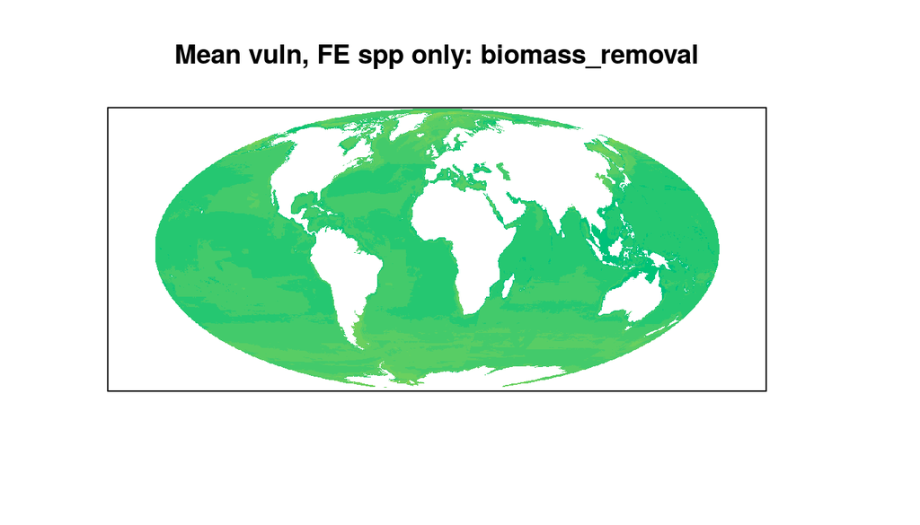

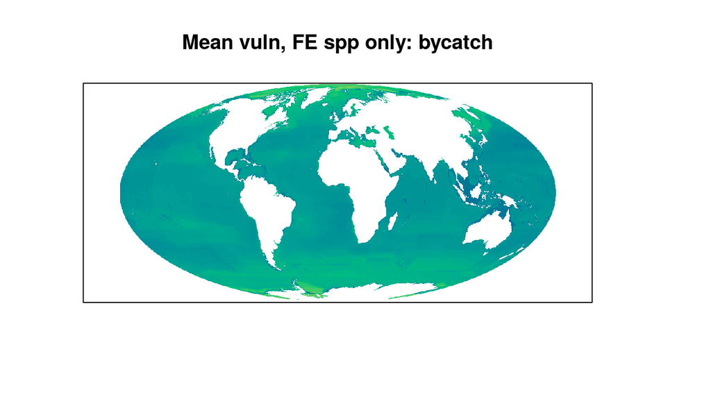

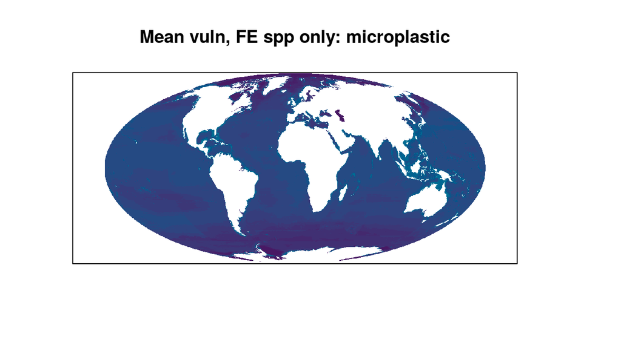

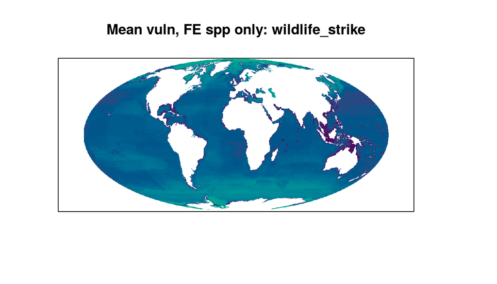

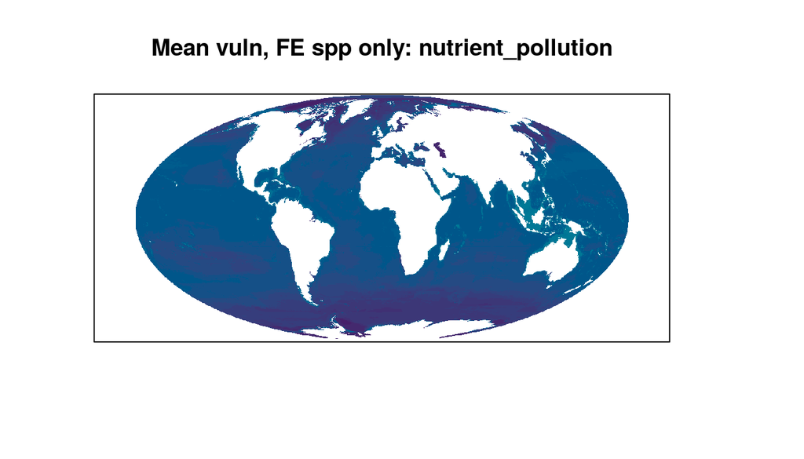

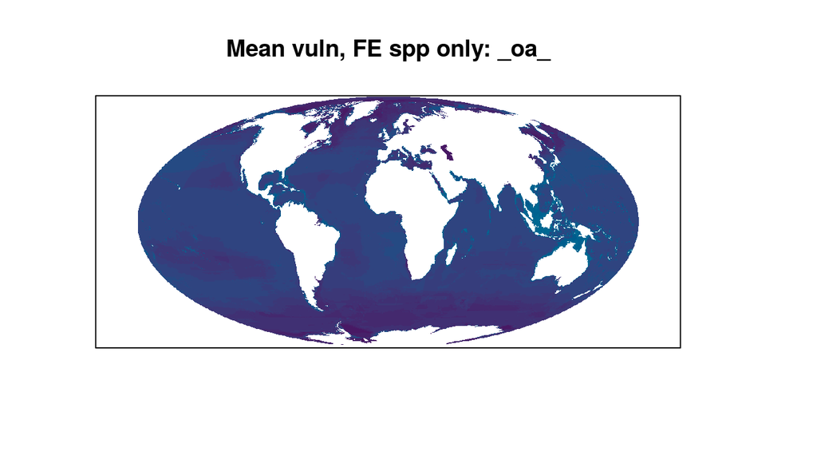

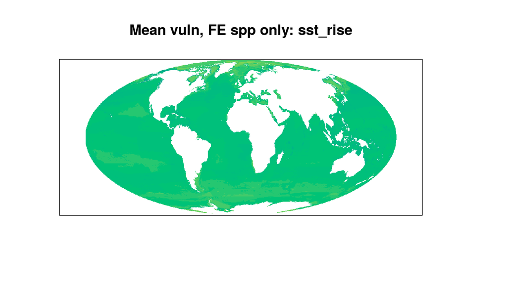

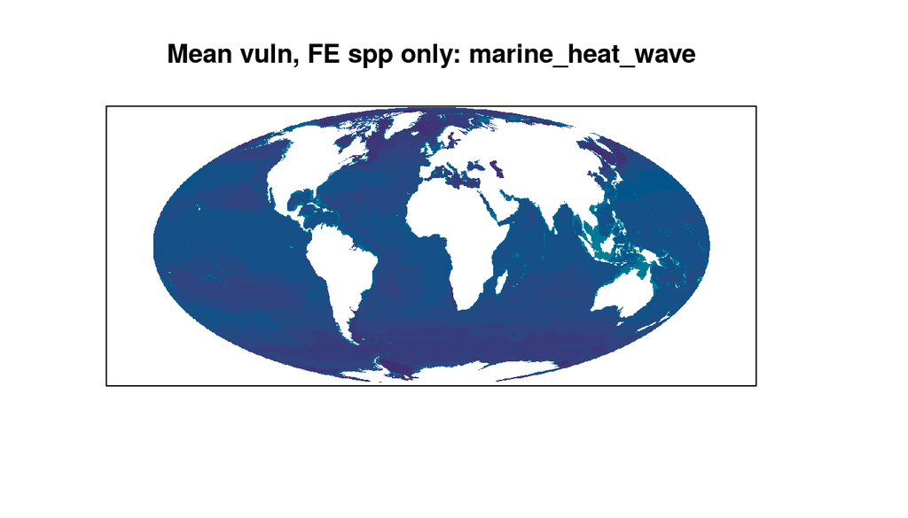

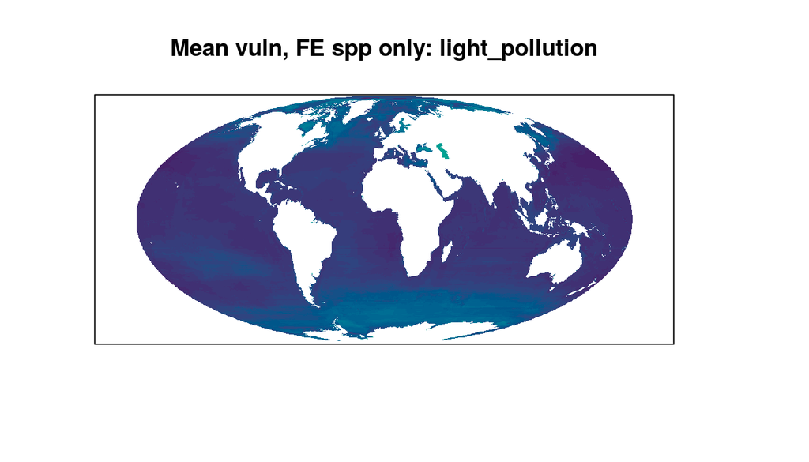

```r
vuln_fe_spp_dir <- here('_output/vuln_maps/vuln_maps_unweighted_fe_only')
mean_fs <- list.files(vuln_fe_spp_dir, pattern = '_mean.tif', full.names = TRUE)
sdev_fs <- list.files(vuln_fe_spp_dir, pattern = '_sdev.tif', full.names = TRUE)

focal_strs <- c('biomass_removal', 'bycatch',
                'microplastic', 'wildlife_strike',
                'nutrient_pollution', '_oa_',
                'sst_rise', 'marine_heat_wave',
                'light_pollution')

for(f in focal_strs) { ### f <- focal_strs[1]
  mean_f <- mean_fs[str_detect(basename(mean_fs), f)]
  # sdev_f <- sdev_fs[str_detect(basename(sdev_fs), f)]
  mean_rast <- raster::raster(mean_f)
  # sdev_rast <- raster::raster(sdev_f)
  # sd_stack   <- raster::stack(sd_fs) %>%
  #   setNames(str_remove(names(.), 'vuln_by_spp_'))

  map_cols <- hcl.colors(n = 50)

  plot(mean_rast, zlim = c(0, 1), col = map_cols, main = paste0('Mean vuln, FE spp only: ', f),
       legend = FALSE, axes = FALSE)
  # plot(sdev_rast, zlim = c(0, 1), col = map_cols, main = paste0('SD vuln: ', f),
  #      legend = FALSE, axes = FALSE)
}
```